```python
import pylab as pl
from  numpy.random import normal
import numpy as np
import healpy as hp
from scipy  import  signal, polyfit
from scipy.signal import periodogram , csd

from pylab import cm
cmap = cm.get_cmap('RdYlBu')
cmap.set_under('w')
from __future__ import print_function
from ipywidgets import interact, interactive, fixed, interact_manual
import ipywidgets as widgets
```

```python
from IPython.display import HTML

HTML('''<script>
code_show=true;
function code_toggle() {
 if (code_show){
 $('div.input').hide();
 } else {
 $('div.input').show();
 }
 code_show = !code_show
}
$( document ).ready(code_toggle);
</script>
<form action="javascript:code_toggle()"><input type="submit" value="Click here to toggle on/off the raw code."></form>''')
```

# 0. Injecting Gain Drifts

We inject drifts with a $1/f$ dependence with $f_{knee}=150 $ mHz (see PSD below) on all detectors within a detector pair .

The input signal encodes: Monopole + Dipole + CMB T fluctuations. So far, no noise is injected to data.

We estimated maps with MADAM destriper (baseline=60 sec)

## Mitigating leakage

To mitigate the leakage we estimate the gain by regressing the signal against a template encoding the **CMB T** with $\ell \gtrsim 50$.

Below are the mitigation steps to a generic TOD $d_t$:

1. Consider a small chunk of $d_t$ corresponding to a given timescale $\tau$ of 10 min.
2. Apply a high-pass filter to $d_{t , t+\tau} $ with cutoff frequency $f_{c}=10$ mHz $^{(1)}$
3. Regress $d_{t , t+\tau} $ against a template $T$ and estimate the regression slope $\hat{g}$ as $$ \hat{g} = \frac { T^{t} d } { T^{t} T } $$ We tested three different regression techniques:
   - `TOD regr.1` : In this post I want to compare 3 different techniques of regression to check which one is the best in actually tracking the gain drifts on a time scale of $\tau =10 $ min. As you can see this technique relies on fitting against a template TOD, $T$.
   - `TOD regr. 2` : We can also find the slope between the two detector pairs TOD by fitting a straight line across each chunk of data. One of the pro of this choice is the fact that we don't rely on a template to fit the gain drifts, but it might be strongly affected by noise. I chose as a low frequency band the range between 10 to 200 mHz.
   - `PSD regr.` : The third rel. gain correction technique I've studied is described in [this post by Sinan](http://bicep.rc.fas.harvard.edu/keck/analysis_logbook/analysis/20151014_relgain_estimators/) and it relies on fitting the gain variations as the ratio between the low frequency band amplitudes of the cross spectrum `diff x sum` and PSD of pair sums.
4. The gain correction $d_{t , t+\tau} $ is then applied in the TOD of each detector : $$ \tilde{d} _{t , t+\tau} = d_{t , t+\tau} / \hat{g} $$

I've compared the performances of the three mitigation techniques, by changing the input signals. The sections below refers to three cases starting from an input signal including Monopole+ Dipole+ CMB T to a simple input signal with just the high frequency signal, i.e. CMB T. Each section show the case with and without the High Pass filter (HPF) .

Since the T-P leakage in the PairDiff is proportional to the gain mismatches, defined as $\delta g = (g^A - g^B)/2$, we plot this quantity and check which technique is able to reconstruct the gain variations as a function of time.

$^{(1)}$ Given an $\ell_c$ (to retain only signal @ $\ell> \ell_c$ ) we estimate $ f_c$ as : $$ \ell_c = 2 \pi f_c/ \omega_{scan} $$ $\omega_{scan} $ is the scanning speed and it 's defined as : $$ \omega_{scan} = \sin (\beta ) * spinrate = 0.0013 rad/sec =0.07 deg/sec$$ Where $\beta$ is the angle between the boresight and the spin axis (50 deg according to latest values) , and the spin rate is 0.1 rpm .

thus, if $\ell_c=50$ , $f_c= 10$ mHz

## 1. Gain Drifts (Monopole+Dipole +CMB T)

```python
fs = 20.  ; fknee=0.15; fcutoff=0.01
```

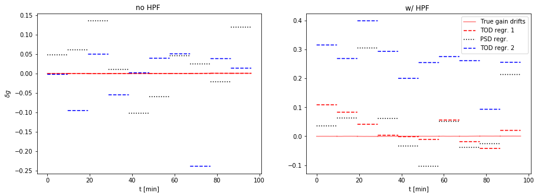

```python
wfilt=pl.load('/Users/peppe/work/satellite_sims/drifting_gain/filttod_MCD.npy')
wdrift=pl.load('/Users/peppe/work/satellite_sims/drifting_gain/drifttod_MCD.npy') ;
wsig=pl.load('/Users/peppe/work/satellite_sims/drifting_gain/signaltod_MCD.npy') ;
gains  = pl.load('/Users/peppe/work/satellite_sims/drifting_gain/gains.npy')
ge = pl.load('/Users/peppe/work/satellite_sims/drifting_gain/gains_coeff.npy')
N= int(gains.shape[1]/len(ge))
T0 = 60*.1603005
fig = pl.figure(figsize=(15,5))
for i in range(10):
    dA = wdrift[i, 0,:] ; dB = wdrift[i, 1,:]; T=wsig[i,0,:]
    g = ( gains [0, i*N:(i+1)*N ]  - gains[1, i*N :(i+1)*N ] )/2
    alpha0= pl.dot(dA , T) / pl.norm(T)**2
    alpha1= pl.dot(dB , T) / pl.norm(T)**2
    alpha= (alpha0 -alpha1)/2
    p0 =polyfit(dA, dB, deg=1)[0]
    t =pl.arange(i*N ,(i+1)*N )/fs  /60
    s= dB +dA
    d= dB - dA

    f1,Pss= periodogram(s,    fs=fs, scaling='density')
    f1,Psd= csd(s,d, fs=fs , scaling='density',nperseg=d.shape[0] )
    mask = pl.ma.masked_inside(f1,1e-2, 2e-1).mask
    delta = (Psd.real[mask].sum() / Pss[mask].sum())
    if i ==0:
        pl.subplot(121)
        pl.xlabel('t [min]')
        pl.ylabel(r'$ \delta g$')
        pl.title('no HPF ')
        pl.plot(t,( g),'r',alpha=.5);     pl.plot(t, pl.ones(N)*(alpha),'r--', label='TOD regr. 1');
        pl.plot(t, pl.ones(N)*(-delta),'k:', label='PSD regr.');
        pl.plot(t, pl.ones(N)*(1 -p0 )/2,'b--', label='TOD regr. 2');
    else :
        pl.subplot(121)
        pl.plot(t,( g),'r',alpha=.5);     pl.plot(t, pl.ones(N)*(alpha),'r--');pl.plot(t, pl.ones(N)*(-delta),'k:');
        pl.plot(t, pl.ones(N)*(1 -p0 )/2,'b--');


    dA = wfilt[i, 0,:] ; dB = wfilt[i, 1,:]; T=wsig[i,1,:]
    g = ( gains [0, i*N:(i+1)*N ]  - gains[1, i*N :(i+1)*N ] )/2
    alphaf0= pl.dot(dA , T) / pl.norm(T)**2
    alphaf1= pl.dot(dB , T) / pl.norm(T)**2
    alpha= (alphaf0 -alphaf1)/2
    p0 =polyfit(dA, dB, deg=1)[0]
    t =pl.arange(i*N ,(i+1)*N )/fs  /60
    s= dB +dA
    d= dB - dA

    f1,Pss= periodogram(s,    fs=fs, scaling='density')
    f1,Psd= csd(s,d, fs=fs ,  scaling='density',nperseg=d.shape[0] )
    mask = pl.ma.masked_inside(f1,1e-2, 2e-1).mask
    delta = (Psd.real[mask].sum() / Pss[mask].sum())
    if i ==0:
        pl.subplot(122)
        pl.title('w/ HPF ')
        pl.xlabel('t [min]')

        pl.plot(t,( g),'r',alpha=.5, label='True gain drifts');     pl.plot(t, pl.ones(N)*(alpha),'r--', label='TOD regr. 1');
        pl.plot(t, pl.ones(N)*(-delta),'k:', label='PSD regr.');
        pl.plot(t, pl.ones(N)*(1 -p0 )/2,'b--', label='TOD regr. 2');
        pl.legend()
    else :
        pl.subplot(122)
        pl.plot(t,( g),'r',alpha=.5);     pl.plot(t, pl.ones(N)*(alpha),'r--');pl.plot(t, pl.ones(N)*(-delta),'k:');
        pl.plot(t, pl.ones(N)*(1 -p0 )/2,'b--');


pl.show()
```

**Fig1.1** : (left) Gain reconstruction without HPF. All the gain estimation techniques fail in reconstructing drifts but `TOD regr.1`. The gain variations are of the order of $10^{-4}$ whereas `TOD regr.2` and `PSD regr` gain estimates are about 3 orders of magnitude larger. (right) Gain reconstruction with HPF applied to the data. None of the 3 technique is able to track the gain variations.

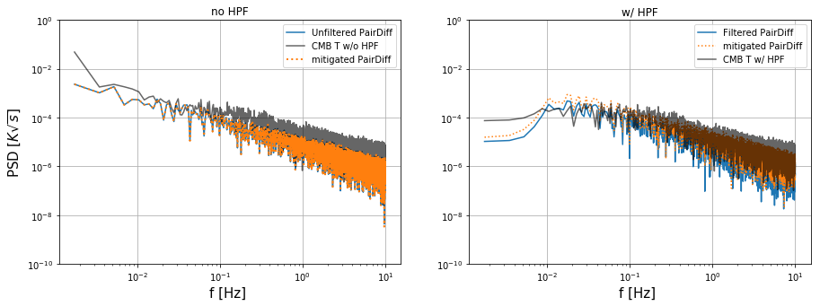

```python
fig = pl.figure(figsize=(15,5))

dA =   wfilt[i, 0,: ]  ; dB =  wfilt[i, 1,:];
s= (dB +dA )/2
d= (dB - dA )/2
T = wsig [i,1,:]
f1,Pss= periodogram(s,    fs=fs, scaling='density')
f1,Pdd= periodogram(d,    fs=fs, scaling='density')

pl.subplot(122)
pl.title('w/ HPF')

#pl.loglog(f1,pl.sqrt( Pss), label='Filtered PairSum')
pl.loglog(f1,pl.sqrt( Pdd), label='Filtered PairDiff')
s= dB/alphaf1 +dA  /alphaf0
d= dB/alphaf1 -dA  /alphaf0
f1,Psig= periodogram(T,    fs=fs, scaling='density')

f1,Pss_m= periodogram(s,    fs=fs, scaling='density')
f1,Pdd_m= periodogram(d,    fs=fs, scaling='density')

pl.ylim([1e-10,1e0])

#pl.loglog(f1,pl.sqrt( Pss_m), ':', label='mitigated PairSum')
pl.loglog(f1,pl.sqrt( Pdd_m), ':', label='mitigated PairDiff')
pl.loglog(f1,pl.sqrt( Psig), 'k',alpha=.6, label='CMB T w/ HPF')
pl.xlabel('f [Hz] ', fontsize=15);

pl.legend()
pl.grid(True)

T = wsig [i,0,:]
dA =   wdrift[i, 0,: ]  ; dB =  wdrift[i, 1,:];
s=(dB +dA )/2
d= (dB - dA )/2
f1,Psig= periodogram(T,    fs=fs, scaling='density')

f1,Pss= periodogram(s,    fs=fs, scaling='density')
f1,Pdd= periodogram(d,    fs=fs, scaling='density')
pl.subplot(121)

pl.xlabel('f [Hz] ', fontsize=15);
pl.ylabel('PSD ['+r'$K \sqrt{s}$]', fontsize=15)
#pl.loglog(f1,pl.sqrt( Pss), label='Unfiltered PairSum')
pl.loglog(f1,pl.sqrt( Pdd),label='Unfiltered PairDiff')
s= ( dB/alpha1 +dA  /alpha0 )/2.
d= (dB/alpha1 -dA  /alpha0 )/2.

f1,Pss_m= periodogram(s,    fs=fs, scaling='density')
f1,Pdd_m= periodogram(d,    fs=fs, scaling='density')

pl.title('no HPF')
pl.loglog(f1,pl.sqrt( Psig), 'k',alpha=.6, label='CMB T w/o HPF')
pl.ylim([1e-10,1e0])
#pl.loglog(f1,pl.sqrt( Pss_m), ':',  label='mitigated PairSum')
pl.loglog(f1,pl.sqrt( Pdd_m),  ':',lw = 2 , label='mitigated PairDiff')
pl.grid(True)
pl.legend()
```

**Fig.1.2** : (left) PSD of unfiltered PairDiff TOD without (solid blue) and with (dotted orange) mitigation applied on 10 minute chunks of data with the estimates from `TOD regr.1`. (right) PSD of High-Pass filtered Pairdiff TOD legend as in the left panel. As a reference we show the CMB T as solid grey line. The signal leaking into polarization is nearly comparable as the CMB T.

## 2. Gain drifts w/ Dipole +CMB T

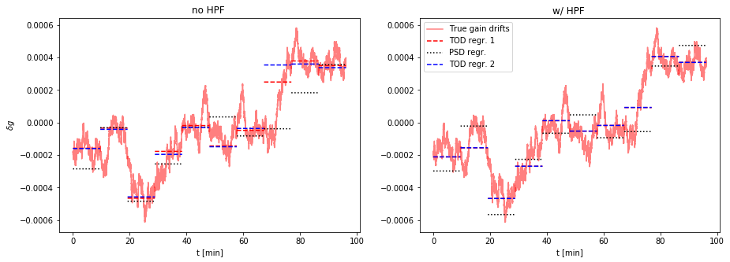

```python
wfilt=pl.load('/Users/peppe/work/satellite_sims/drifting_gain/filttod_CD.npy')
wdrift=pl.load('/Users/peppe/work/satellite_sims/drifting_gain/drifttod_CD.npy') ;
wsig=pl.load('/Users/peppe/work/satellite_sims/drifting_gain/signaltod_CD.npy') ;
gains  = pl.load('/Users/peppe/work/satellite_sims/drifting_gain/gains.npy')
ge = pl.load('/Users/peppe/work/satellite_sims/drifting_gain/gains_coeff.npy')
N= int(gains.shape[1]/len(ge))
T0 = 60*.1603005
fig = pl.figure(figsize=(15,5))
for i in range(10):
    dA = wdrift[i, 0,:] ; dB = wdrift[i, 1,:]; T=wsig[i,0,:]
    g = ( gains [0, i*N:(i+1)*N ]  - gains[1, i*N :(i+1)*N ] )/2
    alpha0= pl.dot(dA , T) / pl.norm(T)**2
    alpha1= pl.dot(dB , T) / pl.norm(T)**2
    alpha= (alpha0 -alpha1)/2
    p0 =polyfit(dA, dB, deg=1)[0]
    t =pl.arange(i*N ,(i+1)*N )/fs  /60
    s= dB +dA
    d= dB - dA


    f1,Pss= periodogram(s,    fs=fs, scaling='density')
    f1,Psd= csd(s,d, fs=fs , scaling='density',nperseg=d.shape[0] )
    mask = pl.ma.masked_inside(f1,1e-2, 2e-1).mask
    delta = (Psd.real[mask].sum() / Pss[mask].sum())
    if i ==0:
        pl.subplot(121)
        pl.xlabel('t [min]')
        pl.ylabel(r'$ \delta g$')
        pl.title('no HPF ')
        pl.plot(t,( g),'r',alpha=.5);     pl.plot(t, pl.ones(N)*(alpha),'r--', label='TOD regr. 1');
        pl.plot(t, pl.ones(N)*(-delta),'k:', label='PSD regr.');
        pl.plot(t, pl.ones(N)*(1 -p0 )/2,'b--', label='TOD regr. 2');
    else :
        pl.subplot(121)
        pl.plot(t,( g),'r',alpha=.5);     pl.plot(t, pl.ones(N)*(alpha),'r--');pl.plot(t, pl.ones(N)*(-delta),'k:');
        pl.plot(t, pl.ones(N)*(1 -p0 )/2,'b--');


    dA = wfilt[i, 0,:] ; dB = wfilt[i, 1,:]; T=wsig[i,1,:]
    g = ( gains [0, i*N:(i+1)*N ]  - gains[1, i*N :(i+1)*N ] )/2
    alphaf0= pl.dot(dA , T) / pl.norm(T)**2
    alphaf1= pl.dot(dB , T) / pl.norm(T)**2
    alpha= (alphaf0 -alphaf1)/2
    p0 =polyfit(dA, dB, deg=1)[0]
    t =pl.arange(i*N ,(i+1)*N )/fs  /60
    s= dB +dA
    d= dB - dA


    f1,Pss= periodogram(s,    fs=fs, scaling='density')
    f1,Psd= csd(s,d, fs=fs ,  scaling='density',nperseg=d.shape[0] )
    mask = pl.ma.masked_inside(f1,1e-2, 2e-1).mask
    delta = (Psd.real[mask].sum() / Pss[mask].sum())
    if i ==0:
        pl.subplot(122)
        pl.title('w/ HPF ')
        pl.xlabel('t [min]')

        pl.plot(t,( g),'r',alpha=.5, label='True gain drifts');     pl.plot(t, pl.ones(N)*(alpha),'r--', label='TOD regr. 1');
        pl.plot(t, pl.ones(N)*(-delta),'k:', label='PSD regr.');
        pl.plot(t, pl.ones(N)*(1 -p0 )/2,'b--', label='TOD regr. 2');
        pl.legend()
    else :
        pl.subplot(122)
        pl.plot(t,( g),'r',alpha=.5);     pl.plot(t, pl.ones(N)*(alpha),'r--');pl.plot(t, pl.ones(N)*(-delta),'k:');
        pl.plot(t, pl.ones(N)*(1 -p0 )/2,'b--');


pl.show()
```

**Fig2.1** : (left) Gain reconstruction without HPF. All the gain estimation techniques are able to reconstruct drifts, though `PSD regr.` looks to be biased to larger fluctuations, The two TOD regression estimates are overall in agreement except in some chunk of date where the gain presents abrupt variations. (right) Gain reconstruction with HPF applied to the data. Notice that in this case the two TOD regr. are perfect in agreement.

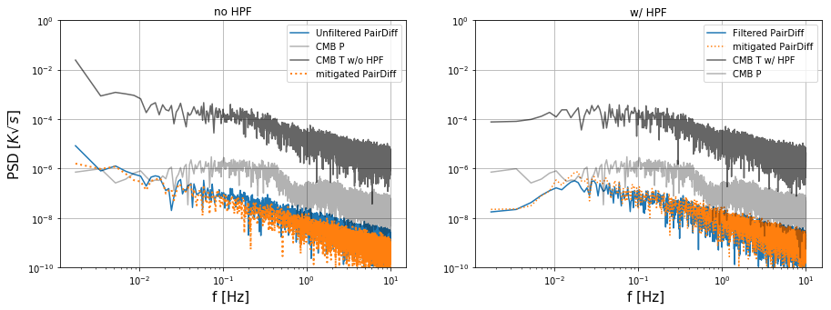

```python
cmbp = pl.load('../drifting_gain/tod_cmbonly.npy' )[0]
fp,Psigp= periodogram((cmbp[0][:N] - cmbp[1][:N])/2. ,    fs=fs, scaling='density')
fig = pl.figure(figsize=(15,5))

dA =   wfilt[i, 0,: ]  ; dB =  wfilt[i, 1,:];
s= (dB +dA )/2
d= (dB - dA )/2
T = wsig [i,1,:]
f1,Pss= periodogram(s,    fs=fs, scaling='density')
f1,Pdd= periodogram(d,    fs=fs, scaling='density')

pl.subplot(122)
pl.title('w/ HPF')

#pl.loglog(f1,pl.sqrt( Pss), label='Filtered PairSum')
pl.loglog(f1,pl.sqrt( Pdd), label='Filtered PairDiff')
s= dB/alphaf1 +dA  /alphaf0
d= dB/alphaf1 -dA  /alphaf0
f1,Psig= periodogram(T,    fs=fs, scaling='density')

f1,Pss_m= periodogram(s,    fs=fs, scaling='density')
f1,Pdd_m= periodogram(d,    fs=fs, scaling='density')

pl.ylim([1e-10,1e0])

#pl.loglog(f1,pl.sqrt( Pss_m), ':', label='mitigated PairSum')
pl.loglog(f1,pl.sqrt( Pdd_m), ':', label='mitigated PairDiff')
pl.loglog(f1,pl.sqrt( Psig), 'k',alpha=.6, label='CMB T w/ HPF')
pl.loglog(fp,pl.sqrt( Psigp), 'k',alpha=.3, label='CMB P  ')

pl.xlabel('f [Hz] ', fontsize=15);

pl.legend()
pl.grid(True)

T = wsig [i,0,:]
dA =   wdrift[i, 0,: ]  ; dB =  wdrift[i, 1,:];
s=(dB +dA )/2
d= (dB - dA )/2
f1,Psig= periodogram(T,    fs=fs, scaling='density')

f1,Pss= periodogram(s,    fs=fs, scaling='density')
f1,Pdd= periodogram(d,    fs=fs, scaling='density')
pl.subplot(121)

pl.xlabel('f [Hz] ', fontsize=15);
pl.ylabel('PSD ['+r'$K \sqrt{s}$]', fontsize=15)
#pl.loglog(f1,pl.sqrt( Pss), label='Unfiltered PairSum')
pl.loglog(f1,pl.sqrt( Pdd),label='Unfiltered PairDiff')
s= ( dB/alpha1 +dA  /alpha0 )/2.
d= (dB/alpha1 -dA  /alpha0 )/2.

f1,Pss_m= periodogram(s,    fs=fs, scaling='density')
f1,Pdd_m= periodogram(d,    fs=fs, scaling='density')

pl.title('no HPF')
pl.loglog(fp,pl.sqrt( Psigp), 'k',alpha=.3, label='CMB P  ')

pl.loglog(f1,pl.sqrt( Psig), 'k',alpha=.6, label='CMB T w/o HPF')
pl.ylim([1e-10,1e0])
#pl.loglog(f1,pl.sqrt( Pss_m), ':',  label='mitigated PairSum')
pl.loglog(f1,pl.sqrt( Pdd_m),  ':',lw = 2 , label='mitigated PairDiff')
pl.grid(True)
pl.legend()
```

**Fig.2.2** : (left) PSD of unfiltered PairDiff TOD without (solid blue) and with (dotted orange) mitigation applied on 10 minute chunks of data with the estimates from `TOD regr.1`. (right) PSD of High-Pass filtered Pairdiff TOD legend as in the left panel. As a reference we show the CMB T and P respectively as solid dark and light grey lines . Since the monopole is absent in this case, the signal leaking into polarization is about 3 orders of magnitude smaller than the leakage shown in fig. 1.2 .

## 3. Gain drifts w/ CMB T

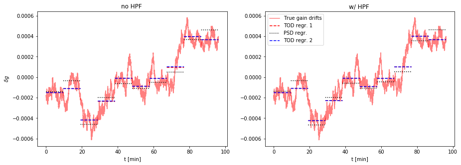

```python
wfilt=pl.load('/Users/peppe/work/satellite_sims/drifting_gain/filttod_C.npy')
wdrift=pl.load('/Users/peppe/work/satellite_sims/drifting_gain/drifttod_C.npy') ;
wsig=pl.load('/Users/peppe/work/satellite_sims/drifting_gain/signaltod_C.npy') ;
gains  = pl.load('/Users/peppe/work/satellite_sims/drifting_gain/gains.npy')
ge = pl.load('/Users/peppe/work/satellite_sims/drifting_gain/gains_coeff.npy')
N= int(gains.shape[1]/len(ge))
T0 = 60*.1603005
fig = pl.figure(figsize=(15,5))
for i in range(10):
    dA = wdrift[i, 0,:] ; dB = wdrift[i, 1,:]; T=wsig[i,0,:]
    g = ( gains [0, i*N:(i+1)*N ]  - gains[1, i*N :(i+1)*N ] )/2
    alpha0= pl.dot(dA , T) / pl.norm(T)**2
    alpha1= pl.dot(dB , T) / pl.norm(T)**2
    alpha= (alpha0 -alpha1)/2
    p0 =polyfit(dA, dB, deg=1)[0]
    t =pl.arange(i*N ,(i+1)*N )/fs  /60
    s= dB +dA
    d= dB - dA


    f1,Pss= periodogram(s,    fs=fs, scaling='density')
    f1,Psd= csd(s,d, fs=fs , scaling='density',nperseg=d.shape[0] )
    mask = pl.ma.masked_inside(f1,1e-2, 2e-1).mask
    delta = (Psd.real[mask].sum() / Pss[mask].sum())
    if i ==0:
        pl.subplot(121)
        pl.xlabel('t [min]')
        pl.ylabel(r'$ \delta g$')
        pl.title('no HPF ')
        pl.plot(t,( g),'r',alpha=.5);     pl.plot(t, pl.ones(N)*(alpha),'r--', label='TOD regr. 1');
        pl.plot(t, pl.ones(N)*(-delta),'k:', label='PSD regr.');
        pl.plot(t, pl.ones(N)*(1 -p0 )/2,'b--', label='TOD regr. 2');
    else :
        pl.subplot(121)
        pl.plot(t,( g),'r',alpha=.5);     pl.plot(t, pl.ones(N)*(alpha),'r--');pl.plot(t, pl.ones(N)*(-delta),'k:');
        pl.plot(t, pl.ones(N)*(1 -p0 )/2,'b--');


    dA = wfilt[i, 0,:] ; dB = wfilt[i, 1,:]; T=wsig[i,1,:]
    g = ( gains [0, i*N:(i+1)*N ]  - gains[1, i*N :(i+1)*N ] )/2
    alphaf0= pl.dot(dA , T) / pl.norm(T)**2
    alphaf1= pl.dot(dB , T) / pl.norm(T)**2
    alpha= (alphaf0 -alphaf1)/2
    p0 =polyfit(dA, dB, deg=1)[0]
    t =pl.arange(i*N ,(i+1)*N )/fs  /60
    s= dB +dA
    d= dB - dA


    f1,Pss= periodogram(s,    fs=fs, scaling='density')
    f1,Psd= csd(s,d, fs=fs ,  scaling='density',nperseg=d.shape[0] )
    mask = pl.ma.masked_inside(f1,1e-2, 2e-1).mask
    delta = (Psd.real[mask].sum() / Pss[mask].sum())
    if i ==0:
        pl.subplot(122)
        pl.title('w/ HPF ')
        pl.xlabel('t [min]')

        pl.plot(t,( g),'r',alpha=.5, label='True gain drifts');     pl.plot(t, pl.ones(N)*(alpha),'r--', label='TOD regr. 1');
        pl.plot(t, pl.ones(N)*(-delta),'k:', label='PSD regr.');
        pl.plot(t, pl.ones(N)*(1 -p0 )/2,'b--', label='TOD regr. 2');
        pl.legend()
    else :
        pl.subplot(122)
        pl.plot(t,( g),'r',alpha=.5);     pl.plot(t, pl.ones(N)*(alpha),'r--');pl.plot(t, pl.ones(N)*(-delta),'k:');
        pl.plot(t, pl.ones(N)*(1 -p0 )/2,'b--');


pl.show()
```

**Fig3.1** : (left) Gain reconstruction without HPF. All the gain estimation techniques are able to recover drifts. The two TOD regression estimates are overall in agreement both in the case w/o and w/ HPF. (right) Gain reconstruction with HPF applied to the data. Notice that in this case the HPF doesn't look to bias the gain estimates for all the 3 techniques, apart some very slight variation for `PSD regr.` as expected since the the HPF changes the spectra of the TODs.

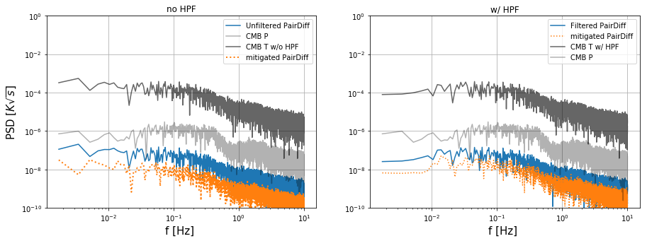

```python
cmbp = pl.load('../drifting_gain/tod_cmbonly.npy' )[0]
fp,Psigp= periodogram((cmbp[0][:N] - cmbp[1][:N])/2. ,    fs=fs, scaling='density')
fig = pl.figure(figsize=(15,5))

dA =   wfilt[i, 0,: ]  ; dB =  wfilt[i, 1,:];
s= (dB +dA )/2
d= (dB - dA )/2
T = wsig [i,1,:]
f1,Pss= periodogram(s,    fs=fs, scaling='density')
f1,Pdd= periodogram(d,    fs=fs, scaling='density')

pl.subplot(122)
pl.title('w/ HPF')

#pl.loglog(f1,pl.sqrt( Pss), label='Filtered PairSum')
pl.loglog(f1,pl.sqrt( Pdd), label='Filtered PairDiff')
s= dB/alphaf1 +dA  /alphaf0
d= dB/alphaf1 -dA  /alphaf0
f1,Psig= periodogram(T,    fs=fs, scaling='density')

f1,Pss_m= periodogram(s,    fs=fs, scaling='density')
f1,Pdd_m= periodogram(d,    fs=fs, scaling='density')

pl.ylim([1e-10,1e0])

#pl.loglog(f1,pl.sqrt( Pss_m), ':', label='mitigated PairSum')
pl.loglog(f1,pl.sqrt( Pdd_m), ':', label='mitigated PairDiff')
pl.loglog(f1,pl.sqrt( Psig), 'k',alpha=.6, label='CMB T w/ HPF')
pl.loglog(fp,pl.sqrt( Psigp), 'k',alpha=.3, label='CMB P  ')

pl.xlabel('f [Hz] ', fontsize=15);

pl.legend()
pl.grid(True)

T = wsig [i,0,:]
dA =   wdrift[i, 0,: ]  ; dB =  wdrift[i, 1,:];
s=(dB +dA )/2
d= (dB - dA )/2
f1,Psig= periodogram(T,    fs=fs, scaling='density')

f1,Pss= periodogram(s,    fs=fs, scaling='density')
f1,Pdd= periodogram(d,    fs=fs, scaling='density')
pl.subplot(121)

pl.xlabel('f [Hz] ', fontsize=15);
pl.ylabel('PSD ['+r'$K \sqrt{s}$]', fontsize=15)
#pl.loglog(f1,pl.sqrt( Pss), label='Unfiltered PairSum')
pl.loglog(f1,pl.sqrt( Pdd),label='Unfiltered PairDiff')
s= ( dB/alpha1 +dA  /alpha0 )/2.
d= (dB/alpha1 -dA  /alpha0 )/2.

f1,Pss_m= periodogram(s,    fs=fs, scaling='density')
f1,Pdd_m= periodogram(d,    fs=fs, scaling='density')

pl.title('no HPF')
pl.loglog(fp,pl.sqrt( Psigp), 'k',alpha=.3, label='CMB P  ')

pl.loglog(f1,pl.sqrt( Psig), 'k',alpha=.6, label='CMB T w/o HPF')
pl.ylim([1e-10,1e0])
#pl.loglog(f1,pl.sqrt( Pss_m), ':',  label='mitigated PairSum')
pl.loglog(f1,pl.sqrt( Pdd_m),  ':',lw = 2 , label='mitigated PairDiff')
pl.grid(True)
pl.legend()
```

**Fig.3.2** : (left) PSD of unfiltered PairDiff TOD without (solid blue) and with (dotted orange) mitigation applied on 10 minute chunks of data with the estimates from `TOD regr.1`. (right) PSD of High-Pass filtered Pairdiff TOD legend as in the left panel. As a reference we show the CMB T and P respectively as solid dark and light grey lines . The signal leaking into polarization is about 3-4 orders of magnitude smaller than the leakage shown in fig. 1.2 . Moreover, the PSD shape is different in this case when compared with both fig. 1.2, and 2.2 . In the plots above the shapes of PSDs (both for blue and orange lines) are dominated by a 1/f signal (perhaps might be related to the gain drifts) whereas in these panels, the PSD morphologies look similar to the CMB T (solid dark grey).

## 4. Summary

- The cases we analyzed in this posting show that several regression techniques can be exploited to mitigate T-P leakage due to gain drifts. The performances depends on what kind of signal is input and how the TODs are preprocessed before estimating the gains.
- Two of the 3 techniques don't rely on a template to be fitted against the data.
- The smaller is the signal the more visible is the effect due to the mitigation.
- Even though gain drifts show frequency variations on a large range of frequencies (from 0.01 to 20 Hz). Perhaps we should low-pass filter the gain timestream to prevent this high freq. variations, which I think are the responsible of biasing the gain estimates in fig.1.2.